# Multiple Regression Analysis Final Report

Chang

2022.12.09

### 一、主題

- 預期壽命的預測

### 二、資料來源

- Life expectancy(WHO)|Kaggle

### 三、文獻回顧

- 2019-2022年間，共有四篇文獻使用這筆資料作分析。
- 2019, 2021 年的文獻有提到開發和已開發國家在預期壽命的預測是不相同的，但都沒有做這項分析。
- 文獻有提及多變數迴歸的方法，但因為要和機器學習比較預測能力，比較少著墨在變數選擇和模型診斷。
- 只有一篇文獻按洲別分類預測，和多變數迴歸都有較好的預測結果(與多項式迴歸比較)。

### 四、動機與目標

- 如果不考慮年度，將所有資料直接放入模型預測不太適當，這次報告先以前一年2013的資料預測2014年的預期壽命。
- 將開發中和已開發國家分別預測，同時加入六大洲的虛擬變數，比較全部國家一起預測的模型，以PMSE為預測能力指標。
- 關心:預測能力的變化、洲變數的影響、模型重要變數選擇差異和係數詮釋。

### 五、資料前處理

```r
# import datasets
setwd("D:/Chang-web/data")
library(readxl)
continents <- read_excel("continents.xlsx")
life <- read_excel("life expectancy.xlsx")
```

1. 合併資料、加入洲變數

```r
# left join
library(tidyverse)
library(dplyr)
continents <- rename(continents, Country = country)
data <- merge(x = life, y = continents, by = "Country", all.x = TRUE) |> relocate(continent, .after = Year)
```

2. 遺失值的處理
- 文獻:平均值或 0 補值、刪除整欄變數。
- 報告處理的方式: 只要有國家在一個(含)以上變數有遺失值，即刪除此國家。
- 並沒有某一欄出現異常多的NA，又因為建模前才要篩選變數，所以刪除NA前，不考慮刪減變數。

```r
sapply(data, function(x) sum(is.na(x)))
```

```
##                         Country                            Year
##                               0                               0
##                       continent                          Status
##                             352                               0
##                 Life expectancy                 Adult Mortality
##                              10                              10
##                   infant deaths                         Alcohol
##                               0                             194
##          percentage expenditure                     Hepatitis B
##                               0                             553
##                         Measles                             BMI
##                               0                              34
##               under-five deaths                           Polio
##                               0                              19
##               Total expenditure                      Diphtheria
##                             226                              19
##                        HIV/AIDS                             GDP
##                               0                             448
##                      Population            thinness  1-19 years
##                             652                              34
##              thinness 5-9 years Income composition of resources
##                              34                             167
##                       Schooling
##                             163
```

```r
data <- na.omit(data)
```

3. 報告使用的資料集 datafull
- 鎖定 2013, 2014 年，對2013建模，對2014預測
- 找出2013~2014年都有資料的國家: 127 個(original number of countries: 129)
- 總資料筆數: 254
- 總變數: 23

```r
y <- data |> filter(Year >= 2013) |> summarise(Year, Country) |> group_by(Country) |> tally()
y <- merge(x = y, y = continents, by = "Country", all.x = TRUE)
y |> filter(n >= 2) |> group_by(continent) |> tally() # 這些國家分布於六大洲
```

```
## # A tibble: 6 × 2
##   continent         n
##   <chr>         <int>
## 1 Africa           40
## 2 Asia             29
## 3 Europe           27
## 4 North America    13
## 5 Oceania           8
## 6 South America    10
```

```r
z <- y |> filter(n >= 2) |> dplyr::select(Country, n)
# status: 1 = developed; 0 = developing
datafull <- merge(x = z, y = data, by = "Country", all.x = TRUE) |>
            filter(Year == 2013 | Year == 2014) |> dplyr::select(-n) |>
            mutate(status = if_else(Status == "Developed", 1, 0)) |>
            relocate(status, .after = continent) |> dplyr::select(-Status)
# 避免格式錯誤:重新命名欄位
datafull <- dplyr::rename(datafull, Life_expectancy = `Life expectancy`)
datafull <- dplyr::rename(datafull, Adult_Mortality = `Adult Mortality`)
datafull <- dplyr::rename(datafull, Hepatitis_B = `Hepatitis B`)
datafull <- dplyr::rename(datafull, under_five_deaths = `under-five deaths`)
datafull <- dplyr::rename(datafull, Total_expenditure = `Total expenditure`)
datafull <- dplyr::rename(datafull, HIV_AIDS = `HIV/AIDS`)
datafull <- dplyr::rename(datafull, thinness_1_19_years = `thinness  1-19 years`)
datafull <- dplyr::rename(datafull, Income_composition_of_resources = `Income composition of resources`)
dat2013 <- datafull |> filter(Year == "2013")
dat2014 <- datafull |> filter(Year == "2014")
```

4. 2013 資料簡介
- 已開發國家幾乎都是歐洲，開發中國家以非洲居多
- 從洲間和國家發展狀態觀察，預期壽命都有些差異
- 文獻討論過洲的差異，這次報告討論開發程度的差異
- 開發和已開發國家最大的預期壽命幾乎相同，但已開發在最小、平均、中位數都多出超過10歲，標準差也比較小，盒狀圖可以看出類似的結果。

```r
ls(dat2013) # 23 variables
```

```
##  [1] "Adult_Mortality"                 "Alcohol"
##  [3] "BMI"                             "continent"
##  [5] "Country"                         "Diphtheria"
##  [7] "GDP"                             "Hepatitis_B"
##  [9] "HIV_AIDS"                        "Income_composition_of_resources"
## [11] "infant deaths"                   "Life_expectancy"
## [13] "Measles"                         "percentage expenditure"
## [15] "Polio"                           "Population"
## [17] "Schooling"                       "status"
## [19] "thinness 5-9 years"              "thinness_1_19_years"
## [21] "Total_expenditure"               "under_five_deaths"
## [23] "Year"
```

```r
str(dat2013)
```

```
## 'data.frame':    127 obs. of  23 variables:
##  $ Country                        : chr  "Afghanistan" "Albania" "Algeria" "Angola" ...
##  $ Year                           : num  2013 2013 2013 2013 2013 ...
##  $ continent                      : chr  "Asia" "Europe" "Africa" "Africa" ...
##  $ status                         : num  0 0 0 0 0 0 1 1 0 0 ...
##  $ Life_expectancy                : num  59.9 77.2 75.3 51.1 76 74.4 82.5 81.1 72.2 71 ...
##  $ Adult_Mortality                : num  268 84 112 355 119 123 61 68 121 135 ...
##  $ infant deaths                  : num  66 0 21 69 8 1 1 0 5 104 ...
##  $ Alcohol                        : num  0.01 4.76 0.53 8.1 8.28 ...
##  $ percentage expenditure         : num  73.2 430.9 544.5 36 1001.8 ...
##  $ Hepatitis_B                    : num  64 99 95 77 94 95 91 95 93 96 ...
##  $ Measles                        : num  430 0 25 8523 0 ...
##  $ BMI                            : num  18.1 56.5 57.2 22.1 61.6 53.3 65.5 56.6 5.6 17 ...
##  $ under_five_deaths              : num  89 1 24 105 10 1 1 0 6 130 ...
##  $ Polio                          : num  62 99 95 67 99 96 91 95 96 96 ...
##  $ Total_expenditure              : num  8.13 5.66 7.12 4.26 4.99 ...
##  $ Diphtheria                     : num  64 99 95 77 94 95 91 95 93 96 ...
##  $ HIV_AIDS                       : num  0.1 0.1 0.1 2.3 0.1 0.1 0.1 0.1 0.1 0.1 ...
##  $ GDP                            : num  632 4415 5472 485 12977 ...
##  $ Population                     : num  31731688 289592 38338562 2599834 42539925 ...
##  $ thinness_1_19_years            : num  17.7 1.3 5.9 8.6 1 2.1 0.6 1.8 2.8 18.3 ...
##  $ thinness 5-9 years             : num  17.7 1.4 5.8 8.5 0.9 2.1 0.6 2 2.8 18.8 ...
##  $ Income_composition_of_resources: num  0.47 0.759 0.737 0.523 0.823 0.736 0.933 0.887 0.745 0.565 ...
##  $ Schooling                      : num  9.9 14.2 14.4 11.4 17.3 12.7 20.3 15.7 11.9 10 ...
```

```r
summary(dat2013)
```

```
##    Country               Year       continent             status
##  Length:127         Min.   :2013   Length:127         Min.   :0.0000
##  Class :character   1st Qu.:2013   Class :character   1st Qu.:0.0000
##  Mode  :character   Median :2013   Mode  :character   Median :0.0000
##                     Mean   :2013                      Mean   :0.1496
##                     3rd Qu.:2013                      3rd Qu.:0.0000
##                     Max.   :2013                      Max.   :1.0000
##  Life_expectancy Adult_Mortality infant deaths        Alcohol
##  Min.   :49.90   Min.   :  6.0   Min.   :   0.00   Min.   : 0.010
##  1st Qu.:65.30   1st Qu.: 68.0   1st Qu.:   0.00   1st Qu.: 0.010
##  Median :71.60   Median :138.0   Median :   3.00   Median : 2.420
##  Mean   :70.47   Mean   :154.2   Mean   :  30.29   Mean   : 3.844
##  3rd Qu.:75.60   3rd Qu.:223.0   3rd Qu.:  21.50   3rd Qu.: 7.220
##  Max.   :87.00   Max.   :518.0   Max.   :1000.00   Max.   :15.040
##  percentage expenditure  Hepatitis_B       Measles             BMI
##  Min.   :    1.042      Min.   : 6.00   Min.   :    0.0   Min.   : 2.10
##  1st Qu.:   39.245      1st Qu.:77.50   1st Qu.:    0.0   1st Qu.:22.25
##  Median :  165.930      Median :92.00   Median :   12.0   Median :45.00
##  Mean   :  760.358      Mean   :81.42   Mean   : 1384.4   Mean   :40.07
##  3rd Qu.:  641.447      3rd Qu.:96.00   3rd Qu.:  231.5   3rd Qu.:58.70
##  Max.   :15515.752      Max.   :99.00   Max.   :52852.0   Max.   :76.70
##  under_five_deaths     Polio      Total_expenditure   Diphtheria
##  Min.   :   0.00   Min.   : 7.0   Min.   : 1.12     Min.   : 8.00
##  1st Qu.:   1.00   1st Qu.:81.5   1st Qu.: 4.54     1st Qu.:82.50
##  Median :   3.00   Median :93.0   Median : 5.94     Median :93.00
##  Mean   :  41.02   Mean   :83.1   Mean   : 6.24     Mean   :86.45
##  3rd Qu.:  30.00   3rd Qu.:97.0   3rd Qu.: 7.86     3rd Qu.:97.00
##  Max.   :1300.00   Max.   :99.0   Max.   :11.97     Max.   :99.00
##     HIV_AIDS           GDP              Population        thinness_1_19_years
##  Min.   :0.1000   Min.   :    14.21   Min.   :      393   Min.   : 0.100
##  1st Qu.:0.1000   1st Qu.:   545.29   1st Qu.:   354590   1st Qu.: 1.500
##  Median :0.1000   Median :  1814.49   Median :  1684432   Median : 3.200
##  Mean   :0.8402   Mean   :  6353.73   Mean   : 13458878   Mean   : 4.751
##  3rd Qu.:0.6000   3rd Qu.:  5829.70   3rd Qu.: 12335102   3rd Qu.: 6.800
##  Max.   :9.6000   Max.   :113751.85   Max.   :181712595   Max.   :26.800
##  thinness 5-9 years Income_composition_of_resources   Schooling
##  Min.   : 0.100     Min.   :0.3410                  Min.   : 5.3
##  1st Qu.: 1.450     1st Qu.:0.5390                  1st Qu.:10.7
##  Median : 3.200     Median :0.7000                  Median :12.7
##  Mean   : 4.723     Mean   :0.6658                  Mean   :12.6
##  3rd Qu.: 6.650     3rd Qu.:0.7730                  3rd Qu.:14.4
##  Max.   :27.500     Max.   :0.9330                  Max.   :20.3
```

```r
table(dat2013$status, dat2013$continent)
```

```
##
##     Africa Asia Europe North America Oceania South America
##   0     40   29      9            13       7            10
##   1      0    0     18             0       1             0
```

```r
dat2013 |> group_by(continent) |> summarise(min_life = min(Life_expectancy),
                                            mean_life = mean(Life_expectancy),
                                            max_life = max(Life_expectancy),
                                            median_life = median(Life_expectancy),
                                            standard_diviation = sd(Life_expectancy))
```

```
## # A tibble: 6 × 6
##   continent     min_life mean_life max_life median_life standard_diviation
##   <chr>            <dbl>     <dbl>    <dbl>       <dbl>              <dbl>
## 1 Africa            49.9      62.1     75.3        62.6               6.74
## 2 Asia              59.9      70.9     82.1        69.5               4.52
## 3 Europe            71        79.1     87          81                 4.56
## 4 North America     62.7      73.9     81.8        73.9               4.78
## 5 Oceania           62.4      70.9     82.5        70.6               6.00
## 6 South America     65.9      74.5     81          75                 3.92
```

```r
dat2013 |> group_by(status) |> summarise(min_life = min(Life_expectancy),
                                         mean_life = mean(Life_expectancy),
                                         max_life = max(Life_expectancy),
                                         median_life = median(Life_expectancy),
                                         standard_diviation = sd(Life_expectancy))
```

```
## # A tibble: 2 × 6
##   status min_life mean_life max_life median_life standard_diviation
##    <dbl>    <dbl>     <dbl>    <dbl>       <dbl>              <dbl>
## 1      0     49.9      68.7       86        69.4               7.62
## 2      1     73        80.3       87        81.1               4.15
```

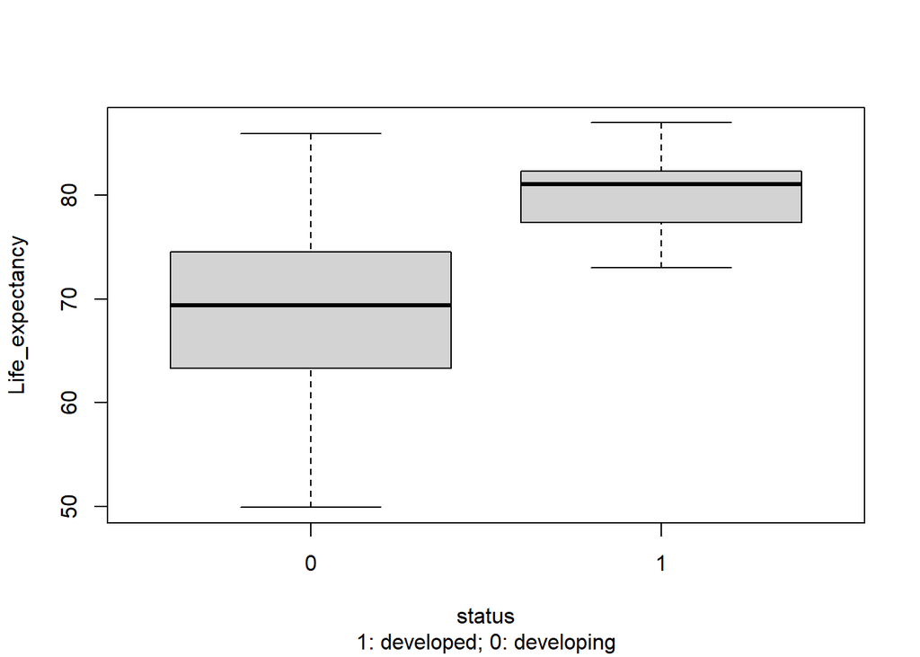

```r
par(mfrow = c(1,1))
boxplot(dat2013$Life_expectancy ~ dat2013$status,
        xlab = c(paste("status"), paste("1: developed; 0: developing")), ylab = "Life_expectancy")
```

5. 初步從盒狀圖、相關係數矩陣圖刪除可能會產生共線性問題的變數
- remove columns having close meaning
  1. GDP: remove “percentage expenditure”
  2. thinness 1-19 years: remove “thinness 5-9 years”
  3. under five deaths: remove “infant deaths

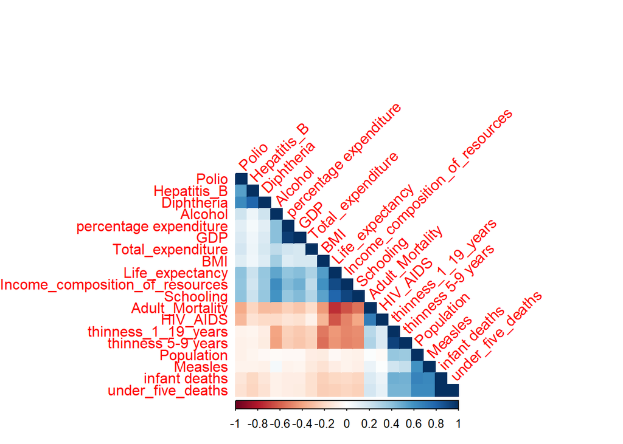

```r
library(corrplot)
corrplot(cor(datafull[,-c(1:4)]), method = "color", tl.srt = 45, type = "lower", order = "hclust")
```

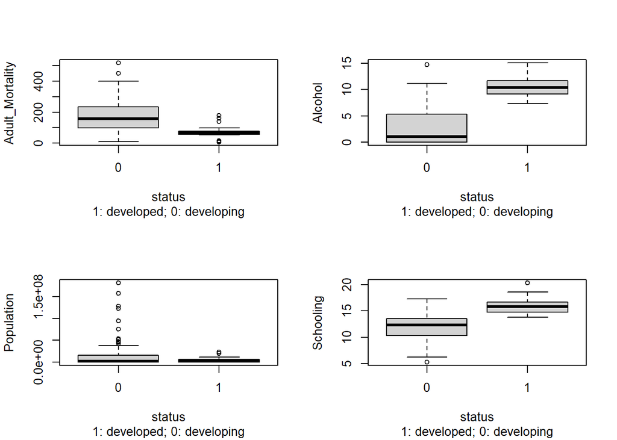

```r
# 社會面變數:成年自殺數(每千人)、15歲以上喝一公升酒的酒精濃度、人口數、就學年數
par(mfrow = c(2,2))
boxplot(dat2013$Adult_Mortality ~ dat2013$status,
        xlab = c(paste("status"), paste("1: developed; 0: developing")), ylab = "Adult_Mortality")
boxplot(dat2013$Alcohol ~ dat2013$status,
        xlab = c(paste("status"), paste("1: developed; 0: developing")), ylab = "Alcohol")
boxplot(dat2013$Population ~ dat2013$status,
        xlab = c(paste("status"), paste("1: developed; 0: developing")), ylab = "Population")
boxplot(dat2013$Schooling ~ dat2013$status,
        xlab = c(paste("status"), paste("1: developed; 0: developing")), ylab = "Schooling")
```

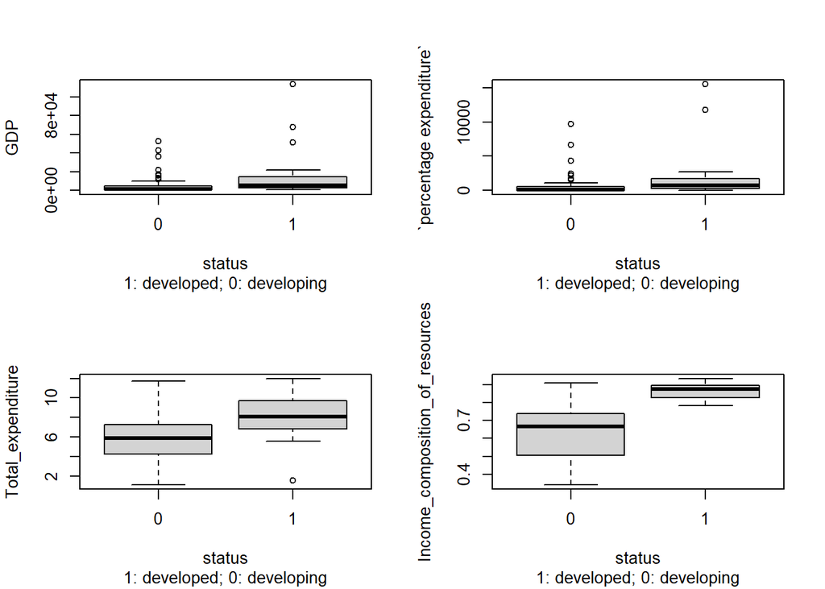

```r
# 經濟面變數:
# percentage expenditure: 健康層面的花費佔GDP的百分比
# total expenditure: 政府在健康支出佔總政府支出的百分比
# income composition of resources: 資源的所得組成百分比
par(mfrow = c(2,2))
boxplot(dat2013$GDP ~ dat2013$status,
        xlab = c(paste("status"), paste("1: developed; 0: developing")), ylab = "GDP")
boxplot(dat2013$`percentage expenditure` ~ dat2013$status,
        xlab = c(paste("status"), paste("1: developed; 0: developing")), ylab = "`percentage expenditure`")
boxplot(dat2013$Total_expenditure ~ dat2013$status,
        xlab = c(paste("status"), paste("1: developed; 0: developing")), ylab = "Total_expenditure")
boxplot(dat2013$Income_composition_of_resources ~ dat2013$status,
        xlab = c(paste("status"), paste("1: developed; 0: developing")), ylab = "Income_composition_of_resources")
```

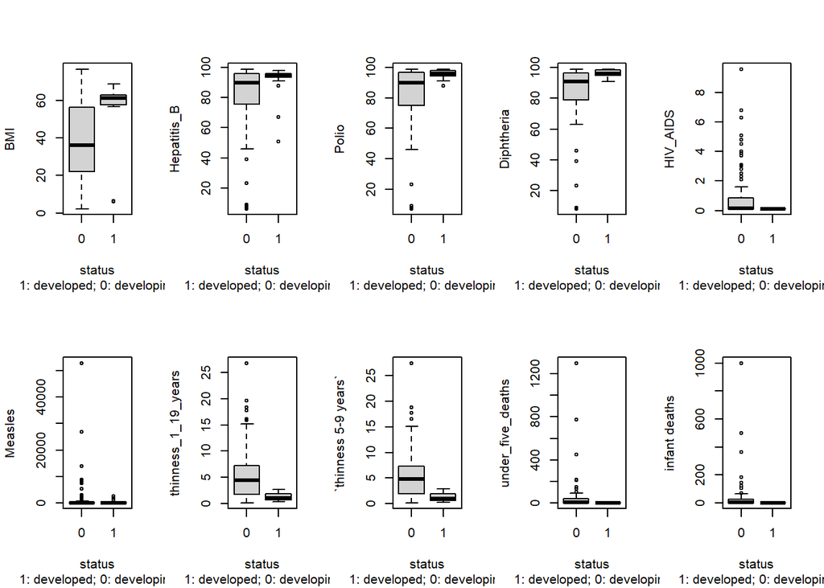

```r
# 健康面變數: BMI，Hepatitis_B(一歲幼童的B型肝炎免疫力%)、Polio(poliomyelitis; 一歲幼童的脊髓灰質炎免疫力%)、Diphtheria(一歲幼童的白喉免疫力%)
# AIDS(0-4歲每千人因為愛滋病死亡的人數)、Measles(每千人患麻疹的通報數)、thinness(過瘦的人口百分比)、infant death(每千人五歲以下幼童死亡率)
par(mfrow = c(2,5))
boxplot(dat2013$BMI ~ dat2013$status,
        xlab = c(paste("status"), paste("1: developed; 0: developing")), ylab = "BMI")
boxplot(dat2013$Hepatitis_B ~ dat2013$status,
        xlab = c(paste("status"), paste("1: developed; 0: developing")), ylab = "Hepatitis_B")
boxplot(dat2013$Polio ~ dat2013$status,
        xlab = c(paste("status"), paste("1: developed; 0: developing")), ylab = "Polio")
boxplot(dat2013$Diphtheria ~ dat2013$status,
        xlab = c(paste("status"), paste("1: developed; 0: developing")), ylab = "Diphtheria")
boxplot(dat2013$HIV_AIDS ~ dat2013$status,
        xlab = c(paste("status"), paste("1: developed; 0: developing")), ylab = "HIV_AIDS")
boxplot(dat2013$Measles ~ dat2013$status,
        xlab = c(paste("status"), paste("1: developed; 0: developing")), ylab = "Measles")
boxplot(dat2013$thinness_1_19_years ~ dat2013$status,
        xlab = c(paste("status"), paste("1: developed; 0: developing")), ylab = "thinness_1_19_years")
boxplot(dat2013$`thinness 5-9 years` ~ dat2013$status,
        xlab = c(paste("status"), paste("1: developed; 0: developing")), ylab = "`thinness 5-9 years`")
boxplot(dat2013$under_five_deaths ~ dat2013$status,
        xlab = c(paste("status"), paste("1: developed; 0: developing")), ylab = "under_five_deaths")
boxplot(dat2013$`infant deaths` ~ dat2013$status,
        xlab = c(paste("status"), paste("1: developed; 0: developing")), ylab = "infant deaths")
```

```r
datafull <- datafull |> dplyr::select(-c(`percentage expenditure`, `thinness 5-9 years`, `infant deaths`))
dat2013 <- datafull |> filter(Year == "2013") # 最後報告用資料的變數為20個
dat2014 <- datafull |> filter(Year == "2014")
```

### 六、資料分析方法、流程與結果

- model 1: full model

```r
# multiple regression
# split data to developed and developing
dat2013ed <- dat2013 |> filter(status == 1)
dat2013ing <- dat2013 |> filter(status == 0)
dat2014ed <- dat2014 |> filter(status == 1)
dat2014ing <- dat2014 |> filter(status == 0)

# full model
library(fastDummies)
dat2013dm <- dat2013 |> dummy_cols(select_columns = "continent")
dat2013dm <- dplyr::rename(dat2013dm, continent_North_America = `continent_North America`)
dat2013dm <- dplyr::rename(dat2013dm, continent_South_America = `continent_South America`)

## let Africa as the base continent
# 顯著的變數:Income_composition_of_resources(+), HIV_AIDS(-), Alcohol(-), Total_expenditure(+), Population(+),
# 洲的變數完全不顯著
# R-squared: 0.86
reg <- lm(Life_expectancy ~. -Year -Country -continent -continent_Africa , data = dat2013dm)
summary(reg)
```

```
##
## Call:
## lm(formula = Life_expectancy ~ . - Year - Country - continent -
##     continent_Africa, data = dat2013dm)
##
## Residuals:
##     Min      1Q  Median      3Q     Max
## -9.1002 -1.9741  0.0571  1.5661 10.4829
##
## Coefficients:
##                                   Estimate Std. Error t value Pr(>|t|)
## (Intercept)                      4.417e+01  2.784e+00  15.865  < 2e-16 ***
## status                           1.543e+00  1.385e+00   1.114  0.26787
## Adult_Mortality                 -6.740e-03  4.200e-03  -1.605  0.11157
## Alcohol                         -2.787e-01  1.298e-01  -2.148  0.03401 *
## Hepatitis_B                     -1.119e-02  1.975e-02  -0.566  0.57229
## Measles                          7.792e-06  8.137e-05   0.096  0.92389
## BMI                             -1.257e-03  2.119e-02  -0.059  0.95282
## under_five_deaths               -2.629e-03  3.835e-03  -0.685  0.49460
## Polio                            4.277e-03  1.670e-02   0.256  0.79842
## Total_expenditure                3.191e-01  1.330e-01   2.399  0.01821 *
## Diphtheria                       3.750e-02  2.874e-02   1.305  0.19469
## HIV_AIDS                        -8.895e-01  2.868e-01  -3.101  0.00247 **
## GDP                              1.222e-05  2.427e-05   0.503  0.61581
## Population                       2.680e-08  1.252e-08   2.141  0.03455 *
## thinness_1_19_years             -5.985e-02  1.053e-01  -0.568  0.57104
## Income_composition_of_resources  4.122e+01  6.722e+00   6.132 1.55e-08 ***
## Schooling                       -3.247e-01  2.935e-01  -1.106  0.27110
## continent_Asia                   1.264e-01  1.118e+00   0.113  0.91015
## continent_Europe                 1.926e+00  1.571e+00   1.226  0.22297
## continent_North_America          2.197e+00  1.343e+00   1.636  0.10485
## continent_Oceania                8.301e-01  1.545e+00   0.537  0.59219
## continent_South_America          2.201e+00  1.534e+00   1.435  0.15431
## ---
## Signif. codes:  0 '***' 0.001 '**' 0.01 '*' 0.05 '.' 0.1 ' ' 1
##
## Residual standard error: 3.114 on 105 degrees of freedom
## Multiple R-squared:  0.8827, Adjusted R-squared:  0.8593
## F-statistic: 37.64 on 21 and 105 DF,  p-value: < 2.2e-16
```

```r
# model diagnosis
# from test
# check normality: shapiro wilk test
shapiro.test(reg$residuals) # not normal
```

```
##
##  Shapiro-Wilk normality test
##
## data:  reg$residuals
## W = 0.97224, p-value = 0.01029
```

```r
# check heteroskedastic
library(lmtest)
bptest(reg) # no  heteroscedasticity
```

```
##
##  studentized Breusch-Pagan test
##
## data:  reg
## BP = 11.685, df = 21, p-value = 0.9477
```

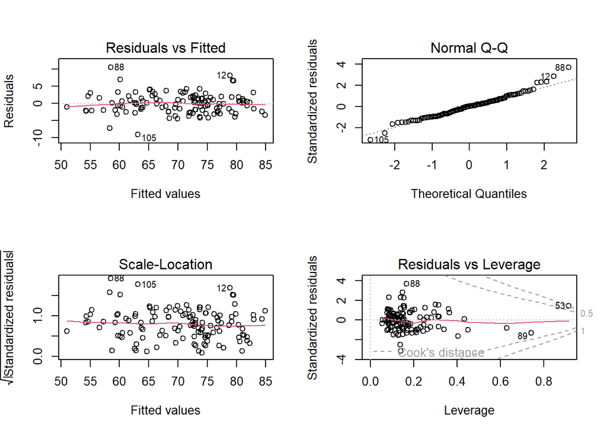

```r
# from plots
par(mfrow = c(2,2))
plot(reg)
```

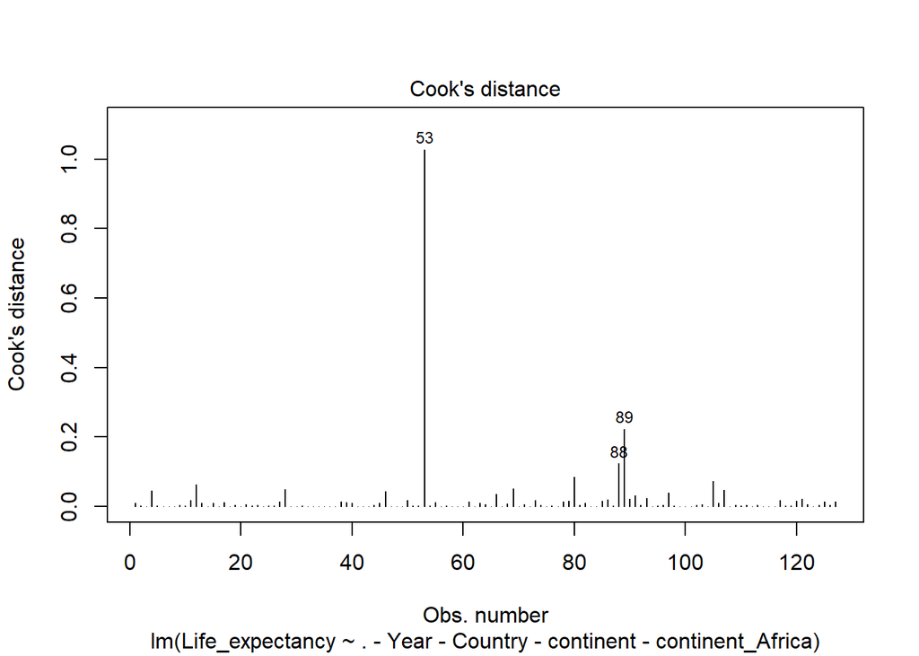

```r
# check influential point by cook's distance
par(mfrow = c(1,1))
plot(reg, which = 4)
```

```r
# 印度在五歲以下死亡人數和過瘦人口比例都是最高
dat2013dm$Country[53] # india
```

```
## [1] "India"
```

```r
library(olsrr)
```

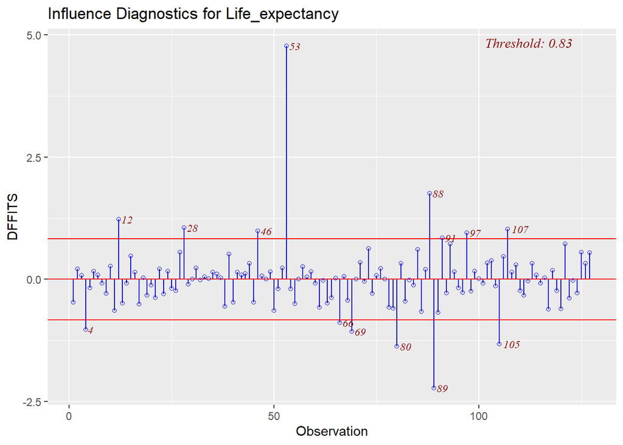

```r
# DFFITS Plot
# cutoff: 2*sqrt(22/127) = 0.832
ols_plot_dffits(reg)
```

```r
# leverage points (hii > 2*22/127=0.35):
dat2013dm$Country[which(lm.influence(reg)$hat > 0.35)]
```

```
## [1] "Australia"  "Chile"      "India"      "Lesotho"    "Luxembourg"
## [6] "Montenegro" "Nigeria"    "Panama"
```

```r
dat2013dm$continent[which(lm.influence(reg)$hat > 0.35)] # 分布於六大洲
```

```
## [1] "Oceania"       "South America" "Asia"          "Africa"
## [5] "Europe"        "Europe"        "Africa"        "North America"
```

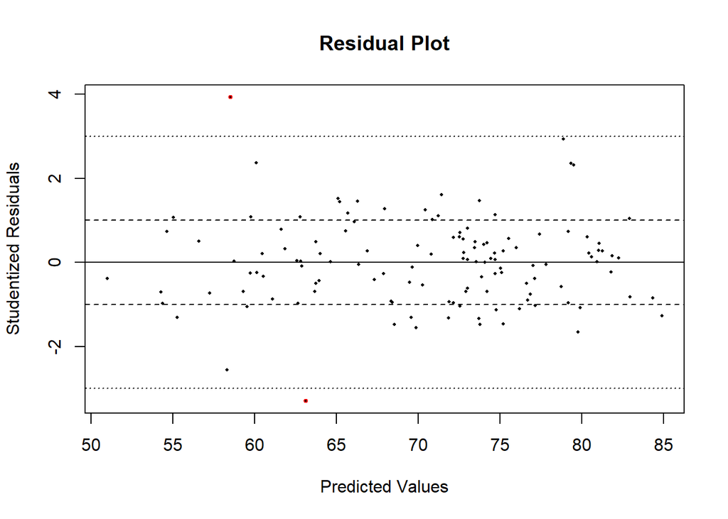

```r
# outlier detection
# studentized residual plot
# handyplots: threshold = +-3 (common)
par(mfrow = c(1,1))
library(handyplots)
library(MASS)
resplot(reg, highlight.outliers = TRUE, residuals = c("student"))
```

```r
# Niger, Sierra Leone
dat2013dm$Country[which(studres(reg) >= 3 | studres(reg) <= -3)]
```

```
## [1] "Niger"        "Sierra Leone"
```

```r
dat2013dm$continent[which(studres(reg) >= 3 | studres(reg) <= -3)] # 都是非洲國家
```

```
## [1] "Africa" "Africa"
```

```r
# remove outlier and influential point
# 顯著的變數: Income_composition_of_resources(+), HIV_AIDS(-), Total_expenditure(+), Adult_Mortality(-), Alcohol(-), Population(+), continent_North_America(+)
# continent_North_America 是正向顯著的變數，代表北美洲國家人民的預期壽命平均會比非洲人民多2歲。
tdat2013dm <- dat2013dm |> filter(Country != "Niger") |> filter(Country != "Sierra Leone") |> filter(Country != "India")
treg <- lm(Life_expectancy ~. -Year -Country -continent -continent_Africa , data = tdat2013dm)
summary(treg)
```

```
##
## Call:
## lm(formula = Life_expectancy ~ . - Year - Country - continent -
##     continent_Africa, data = tdat2013dm)
##
## Residuals:
##     Min      1Q  Median      3Q     Max
## -7.4986 -1.7813  0.0182  1.4730  8.6120
##
## Coefficients:
##                                   Estimate Std. Error t value Pr(>|t|)
## (Intercept)                      4.367e+01  2.744e+00  15.917  < 2e-16 ***
## status                           1.320e+00  1.235e+00   1.069  0.28776
## Adult_Mortality                 -9.411e-03  3.817e-03  -2.466  0.01534 *
## Alcohol                         -2.790e-01  1.158e-01  -2.410  0.01776 *
## Hepatitis_B                     -5.992e-03  1.776e-02  -0.337  0.73654
## Measles                          1.865e-04  1.240e-04   1.503  0.13583
## BMI                             -3.989e-03  1.893e-02  -0.211  0.83354
## under_five_deaths               -1.610e-02  9.024e-03  -1.785  0.07731 .
## Polio                            4.089e-03  1.492e-02   0.274  0.78452
## Total_expenditure                3.795e-01  1.210e-01   3.136  0.00224 **
## Diphtheria                       3.135e-02  2.593e-02   1.209  0.22953
## HIV_AIDS                        -7.510e-01  2.592e-01  -2.898  0.00460 **
## GDP                              1.001e-05  2.168e-05   0.462  0.64520
## Population                       3.567e-08  1.362e-08   2.618  0.01018 *
## thinness_1_19_years              2.861e-02  9.724e-02   0.294  0.76921
## Income_composition_of_resources  3.925e+01  6.048e+00   6.491 3.14e-09 ***
## Schooling                       -1.990e-01  2.655e-01  -0.750  0.45520
## continent_Asia                  -9.060e-02  1.001e+00  -0.091  0.92804
## continent_Europe                 2.100e+00  1.410e+00   1.489  0.13949
## continent_North_America          2.440e+00  1.209e+00   2.019  0.04615 *
## continent_Oceania                1.276e+00  1.387e+00   0.919  0.36007
## continent_South_America          2.541e+00  1.371e+00   1.853  0.06677 .
## ---
## Signif. codes:  0 '***' 0.001 '**' 0.01 '*' 0.05 '.' 0.1 ' ' 1
##
## Residual standard error: 2.775 on 102 degrees of freedom
## Multiple R-squared:  0.9065, Adjusted R-squared:  0.8872
## F-statistic: 47.07 on 21 and 102 DF,  p-value: < 2.2e-16
```